# Analyzing the effectiveness of Training on Attrition

# 7 Detailed EDA: Questions raised in base EDA

## 7.1 How many months more from their TotalWorking hours should employees spend in their current role before being put into Training?

```r
 demo5 <- df%>%group_by(Training,Attrition) %>% summarise(PercentageofyearsinCuurrRole = mean(YearsInCurrentRole)/mean(TotalWorkingYears)*100,n = n()) %>% ungroup()
 sub_title = paste0("Employees who leave with attrion have the least monthly income")

 demo5<-demo5 %>% mutate(scenario = as.factor(paste(Training,Attrition)),
                              scenario = factor(scenario,
                                                levels = c("No 0","No 1","Yes 0","Yes 1"),
                                                labels = c('NoTraining & NoAttrition', 'NoTraining & Attrition',"Training & NoAttrition", "Training & Attrition")
                              )
 )
 demo5
```

```
## # A tibble: 4 x 5
##   Training Attrition PercentageofyearsinCuurrRole     n scenario
##   <chr>    <fct>                            <dbl> <int> <fct>
## 1 No       0                                 38.4   172 NoTraining & NoAt~
## 2 No       1                                 41.5    38 NoTraining & Attr~
## 3 Yes      0                                 37.7  1061 Training & NoAttr~
## 4 Yes      1                                 33.7   199 Training & Attrit~
```

## 7.2 How many months from their TotalWorking hours should employees spend with their manager before being put into Training?

```r
 demo6 <- df%>%group_by(Training,Attrition) %>% summarise(PercentageofyearswithManager = mean(YearsWithCurrManager)/mean(TotalWorkingYears)*100,n = n()) %>% ungroup()
 sub_title = paste0("Employees who leave with attrion have the least monthly income")

 demo6<-demo6 %>% mutate(scenario = as.factor(paste(Training,Attrition)),
                              scenario = factor(scenario,
                                                levels = c("No 0","No 1","Yes 0","Yes 1"),
                                                labels = c('NoTraining & NoAttrition', 'NoTraining & Attrition',"Training & NoAttrition", "Training & Attrition")
                              )
 )
 demo6
```

```
## # A tibble: 4 x 5
##   Training Attrition PercentageofyearswithManager     n scenario
##   <chr>    <fct>                            <dbl> <int> <fct>
## 1 No       0                                 37.2   172 NoTraining & NoAt~
## 2 No       1                                 35.4    38 NoTraining & Attr~
## 3 Yes      0                                 36.7  1061 Training & NoAttr~
## 4 Yes      1                                 34.4   199 Training & Attrit~
```

# 8 Statistical Analysis

Hypothesis for the first finding:

Null hypothesis: Training has no effect on attrion because of years spent in current role

Alternate hypothesis: Training has effect on attrion because of years spent in current role

Hypothesis for the second finding:

Null hypothesis: Training has no effect on attrion because of years spent with manager

Alternate hypothesis:Training has effect on attrion because of years spent with manger

## 8.1 Visualize First Finding

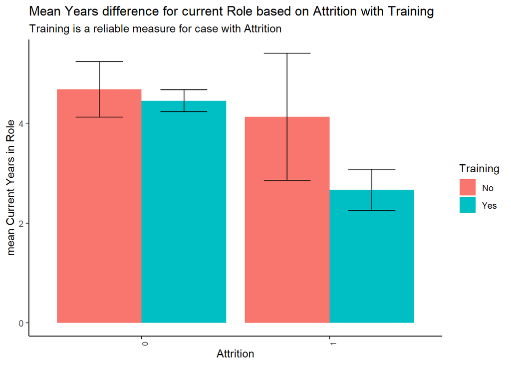

```r
 # 95% CI, get z-value for upper tail, use 0.975 since is one sided
 z <- qnorm(0.975)

 # Incorporate CI into bar graph of means
sig_curr<-df %>%
     group_by(Attrition,Training) %>%
     summarise(mean = mean(YearsInCurrentRole), sd = sd(YearsInCurrentRole),
               n = n(), ci = z * sd/sqrt(n)) %>%
     ggplot(aes(x = Attrition, y = mean, fill=Training)) +
     geom_bar(stat = "identity", position = "dodge") +
     geom_errorbar(aes(ymin = mean - ci, ymax = mean + ci),
                   width = 0.5, position = position_dodge(0.9)) +
  expand_limits(y=c(0, 5))+
  theme_classic()+
  theme(
       axis.text.x = element_text(angle=90, hjust=1,size = 8))+
  labs(title = "Mean Years difference for current Role based on Attrition with Training",
       subtitle = "Training is a reliable measure for case with Attrition",
       x = "Attrition",
       y = "mean Current Years in Role")
sig_curr
```

## 8.2 Visualize Second Finding

[figure not shown]

```r
 # 95% CI, get z-value for upper tail, use 0.975 since is one sided
 z <- qnorm(0.975)

 # Incorporate CI into bar graph of means
sig_man<-df %>%
     group_by(Attrition,Training) %>%
     summarise(mean = mean(YearsWithCurrManager), sd = sd(YearsWithCurrManager),
               n = n(), ci = z * sd/sqrt(n)) %>%
     ggplot(aes(x = Attrition, y = mea, fill=Training)) +
     geom_bar(stat = "identity", position = "dodge") +
     geom_errorbar(aes(ymin = mean - ci, ymax = mean + ci),
                   width = 0.5, position = position_dodge(0.9)) +
  expand_limits(y=c(0, 5))+
  theme_classic()+
  theme(
       axis.text.x = element_text(angle=90, hjust=1,size = 8))+
  labs(title = "Mean Years difference for time spent with manager based on Attrition with Training",
       subtitle = "Training is a reliable measure for case with Attrition",
       x = "Attrition",
       y = "mean Years with Manager")
sig_curr
```

## 8.3 Logit Regression

```r
summary(glm(df$Attrition~df$MonthlyIncome+df$Training+df$YearsAtCompany+df$YearsInCurrentRole+df$YearsWithCurrManager+df$TotalWorkingYears+as.numeric(df$JobSatisfaction)+df$JobLevel,family = "binomial"))
```

```
##
## Call:
## glm(formula = df$Attrition ~ df$MonthlyIncome + df$Training +
##     df$YearsAtCompany + df$YearsInCurrentRole + df$YearsWithCurrManager +
##     df$TotalWorkingYears + as.numeric(df$JobSatisfaction) + df$JobLevel,
##     family = "binomial")
##
## Deviance Residuals:
##     Min       1Q   Median       3Q      Max
## -1.1329  -0.6499  -0.4550  -0.2954   2.5616
##
## Coefficients:
##                                  Estimate Std. Error z value Pr(>|z|)
## (Intercept)                     6.214e-01  3.361e-01   1.849  0.06447 .
## df$MonthlyIncome               -1.252e-04  6.639e-05  -1.885  0.05939 .
## df$TrainingYes                 -2.260e-01  2.061e-01  -1.097  0.27264
## df$YearsAtCompany               7.750e-02  2.884e-02   2.687  0.00721 **
## df$YearsInCurrentRole          -1.089e-01  3.975e-02  -2.741  0.00613 **
## df$YearsWithCurrManager        -9.541e-02  3.948e-02  -2.417  0.01565 *
## df$TotalWorkingYears           -3.379e-02  1.928e-02  -1.753  0.07960 .
## as.numeric(df$JobSatisfaction) -2.807e-01  6.691e-02  -4.195 2.72e-05 ***
## df$JobLevel2                   -5.704e-01  2.521e-01  -2.263  0.02365 *
## df$JobLevel3                    6.728e-01  5.086e-01   1.323  0.18588
## df$JobLevel4                    1.310e-01  9.802e-01   0.134  0.89372
## df$JobLevel5                    1.120e+00  1.206e+00   0.929  0.35301
## ---
## Signif. codes:  0 '***' 0.001 '**' 0.01 '*' 0.05 '.' 0.1 ' ' 1
##
## (Dispersion parameter for binomial family taken to be 1)
##
##     Null deviance: 1298.6  on 1469  degrees of freedom
## Residual deviance: 1177.1  on 1458  degrees of freedom
## AIC: 1201.1
##
## Number of Fisher Scoring iterations: 5
```

We can see that yearsatcompany,years in currentrole,Job satisfaction,years with current manager are all significant at .05 significance level.

# 9 Summary

Training is not effective because of the following reasons:

- Employees that are training and leave are not satisfied with their jobs because of lower monthly income
- They are put into training without spending sufficient time in their current job role
- They are put into training without spending sufficient time with their manager

Some suggestions for improvment: